# Notebook 25 – Solutions

## Getting Started

Before running this notebook, select “Session > Restart R and Clear Output” in the menu above to start a new R session. This will clear any old data sets and give us a blank slate to start with.

## Italy COVID-19 Data

Today we will look at several datasets concerning Italy and the spread of COVID-19 in the country. The main data contains one row for each combination of province and date. It provides the number of newly diagnosed cases for each date in a given province.

```r
covid <- read_csv("data/it_province_covid.csv")
covid
```

```
## # A tibble: 68,694 × 4
##    date       region     province           cases
##    <date>     <chr>      <chr>              <dbl>
##  1 2020-02-24 Abruzzo    L'Aquila               0
##  2 2020-02-24 Abruzzo    Teramo                 0
##  3 2020-02-24 Abruzzo    Pescara                0
##  4 2020-02-24 Abruzzo    Chieti                 0
##  5 2020-02-24 Basilicata Potenza                0
##  6 2020-02-24 Basilicata Matera                 0
##  7 2020-02-24 Calabria   Cosenza                0
##  8 2020-02-24 Calabria   Catanzaro              0
##  9 2020-02-24 Calabria   Reggio di Calabria     0
## 10 2020-02-24 Calabria   Crotone                0
## # … with 68,684 more rows
```

We also have a dataset of the major Italian cities. These contain longitude and latitude as well as the city’s population.

```r
city <- read_csv("data/italy_cities.csv")
city
```

```
## # A tibble: 388 × 4
##    city_name   lon   lat     pop
##    <chr>     <dbl> <dbl>   <dbl>
##  1 Rome      12.5   41.9 2318895
##  2 Milan      9.19  45.5 1236837
##  3 Naples    14.3   40.9  959470
##  4 Turin      7.69  45.1  870456
##  5 Palermo   13.3   38.1  648260
##  6 Genoa      8.94  44.4  580223
##  7 Bologna   11.3   44.5  366133
##  8 Florence  11.2   43.8  349296
##  9 Catania   15.1   37.5  290927
## 10 Bari      16.9   41.1  277387
## # … with 378 more rows
```

Finally, we have a spatial dataset that contains the 107 Italian provinces.

```r
province <- read_sf("data/it_province.geojson")
province
```

```
## Simple feature collection with 107 features and 1 field
## Geometry type: MULTIPOLYGON
## Dimension:     XY
## Bounding box:  xmin: 6.626621 ymin: 35.49369 xmax: 18.52038 ymax: 47.09178
## Geodetic CRS:  WGS 84
## # A tibble: 107 × 2
##    province                                                                  geometry
##    <chr>                                                           <MULTIPOLYGON [°]>
##  1 Torino                       (((7.89397 45.58222, 7.896535 45.57985, 7.896523 45.…
##  2 Vercelli                     (((7.929003 45.74244, 7.925838 45.74196, 7.924361 45…
##  3 Novara                       (((8.420787 45.82981, 8.420283 45.8301, 8.420233 45.…
##  4 Cuneo                        (((6.945403 44.42794, 6.947343 44.42759, 6.948395 44…
##  5 Asti                         (((7.966847 45.11667, 7.967294 45.11673, 7.967801 45…
##  6 Alessandria                  (((8.408749 44.70687, 8.411585 44.7068, 8.41227 44.7…
##  7 Biella                       (((8.237273 45.70164, 8.247597 45.69494, 8.24768 45.…
##  8 Verbano-Cusio-Ossola         (((8.012179 46.01191, 8.012959 46.01608, 8.016784 46…
##  9 Valle d'Aosta/Vallée d'Aoste (((7.734555 45.92365, 7.735905 45.92744, 7.736187 45…
## 10 Varese                       (((8.579638 45.75172, 8.575321 45.75629, 8.572289 45…
## # … with 97 more rows
```

## Questions

### Cases over Time

Grouping by date, compute the total number of new cases across all provinces. Create a plot with date on the x-axis and cases on the y-axis.

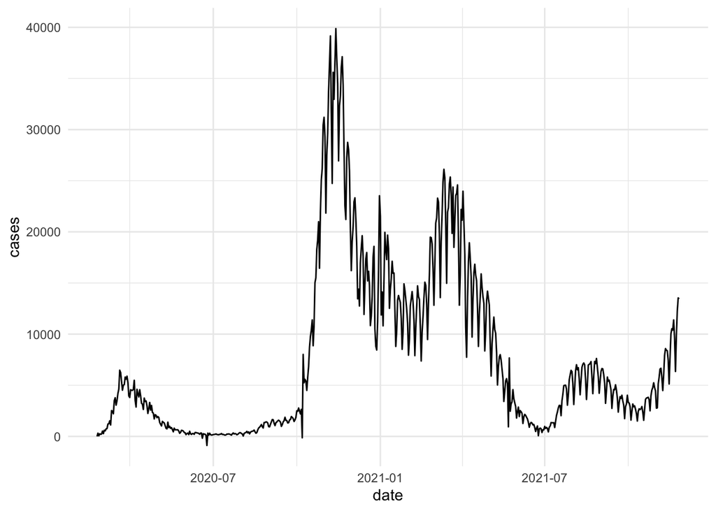

```r
covid %>%
  group_by(date) %>%
  summarize(cases = sum(cases)) %>%
  ggplot(aes(date, cases)) +
    geom_line()
```

Starting with the code you had above, add a `scale_x_date` that has breaks and minor breaks every 3 months. Label the date axis with “%Y %b”.

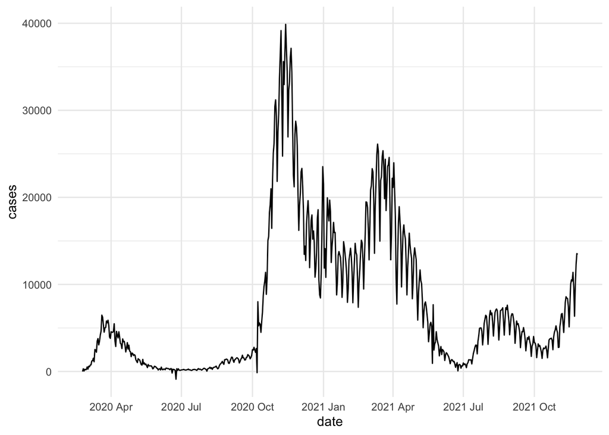

```r
covid %>%
  group_by(date) %>%
  summarize(cases = sum(cases)) %>%
  ggplot(aes(date, cases)) +
    geom_line() +
    scale_x_date(date_breaks = "3 month", date_minor_breaks = "3 month", date_labels = "%Y %b")
```

Modifying the code you had previously, add a rolling mean with `roll_meanr` over 14 days. Include two lines: one for the smoothed mean and the a line of the raw data with a “dotted” linetype a color of “grey75”.

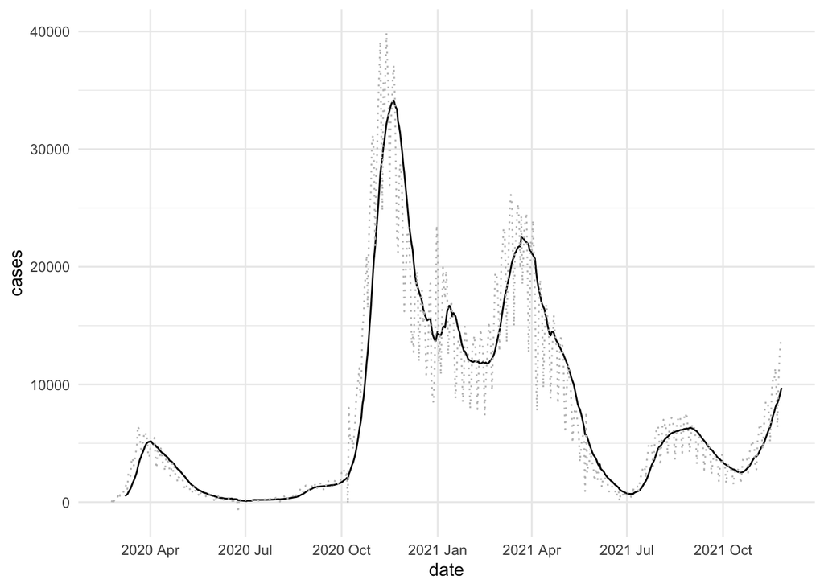

```r
covid %>%
  group_by(date) %>%
  summarize(cases = sum(cases)) %>%
  mutate(cases_smooth = roll_meanr(cases, n = 14)) %>%
  ggplot(aes(date, cases)) +
    geom_line(aes(y = cases_smooth)) +
    geom_line(linetype = "dotted", color = "grey75") +
    scale_x_date(date_breaks = "3 month", date_minor_breaks = "3 month", date_labels = "%Y %b")
```

Notice that the data are very noisy when unsmoothed. Let’s see if this is a day of the week effect. Take the covid data, add a day of the week variable (use a label), group by the day of the week, and compute the average number of cases on each weekday. Take note of any patterns or differences.

```r
covid %>%
  mutate(dow = wday(date, label = TRUE)) %>%
  group_by(dow) %>%
  summarize(cases = mean(cases))
```

```
## # A tibble: 7 × 2
##   dow   cases
##   <ord> <dbl>
## 1 Mon    50.5
## 2 Tue    62.6
## 3 Wed    73.5
## 4 Thu    81.4
## 5 Fri    82.9
## 6 Sat    78.7
## 7 Sun    69.8
```

Returning the last plot you made, create a rolling smoothing line over 7 days and another over 10 days. Plot both lines with different colors and observe which one is noisier. Usually we expect longer times to be smoother, but it will be the opposite here because of the day of the week effect.

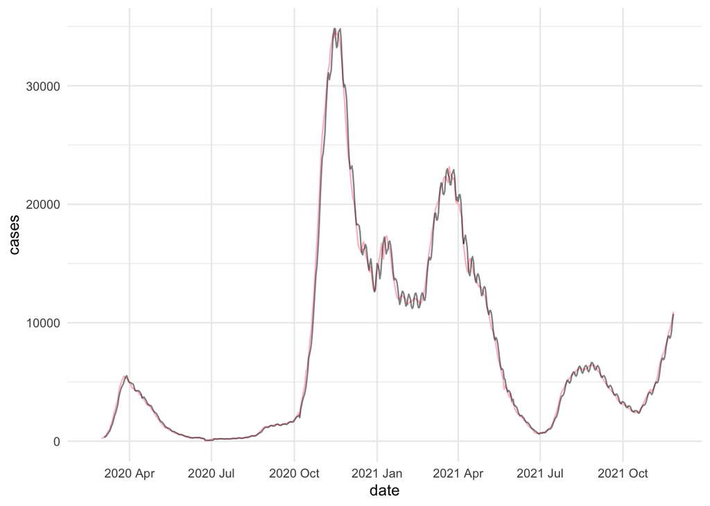

```r
covid %>%
  group_by(date) %>%
  summarize(cases = sum(cases)) %>%
  mutate(cases_smooth_7 = roll_meanr(cases, n = 7)) %>%
  mutate(cases_smooth_10 = roll_meanr(cases, n = 10)) %>%
  ggplot(aes(date, cases)) +
    geom_line(aes(y = cases_smooth_7), color = "pink") +
    geom_line(aes(y = cases_smooth_10), alpha = 0.5) +
    scale_x_date(date_breaks = "3 month", date_minor_breaks = "3 month", date_labels = "%Y %b")
```

### Italian Map

Next, take the `province` dataset and plot the regions. Transform the data set to the CRS code 7794 and fill the regions in the color white.

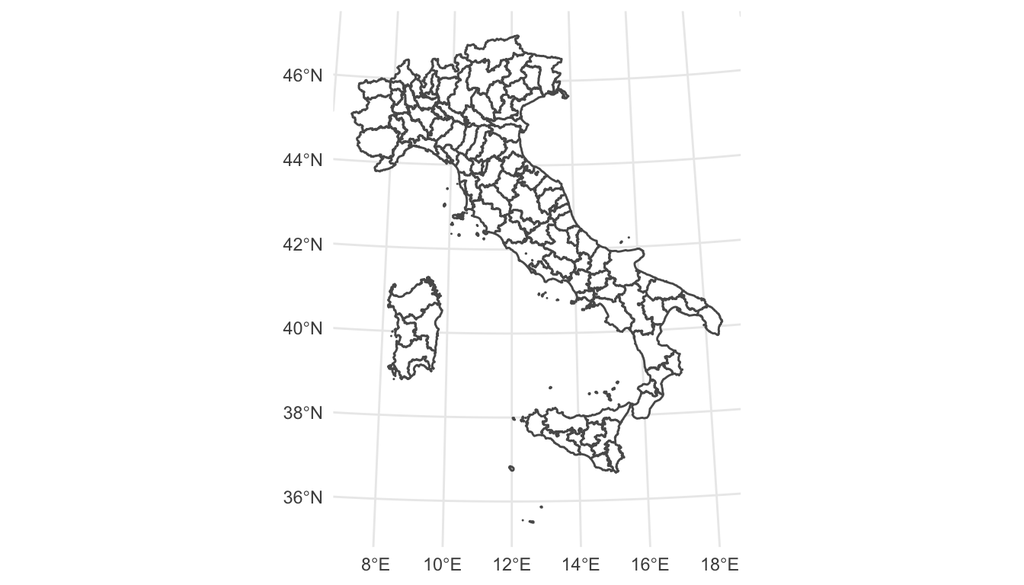

```r
province %>%
  st_transform(7794) %>%
  ggplot() +
    geom_sf(fill = "white")
```

Create a dataset called `city_geo` that is a spatial version of the `city` data. Arrange the dataset in ascenduing order of population (it will make the next plot look nicer).

```r
city_geo <- city %>%
  st_as_sf(coords = c("lon", "lat"), crs = 4326, remove = FALSE) %>%
  arrange(pop)
```

Starting with the plot of provinces that you had above and add a layer of the cities on top. Have the size and color change with respect to the population of the city and use a `scale_color_distiller` to make a nice color scale.

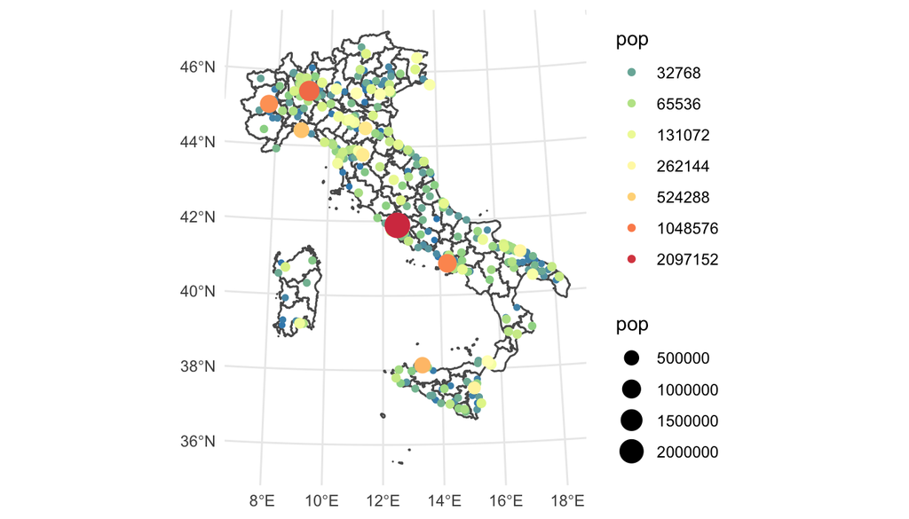

```r
province %>%
  st_transform(7794) %>%
  ggplot() +
    geom_sf(fill = "white") +
    geom_sf(aes(size = pop, color = pop), data = city_geo) +
    scale_color_distiller(
      trans = "log2", palette = "Spectral", guide = "legend", n.breaks = 10
    )
```

Finally, create a data set called `city_geo_lgl` of the largest ten Italian cities. Below, add a `geom_sf_label` to the plot you created above with labels of the city names for these ten cities.

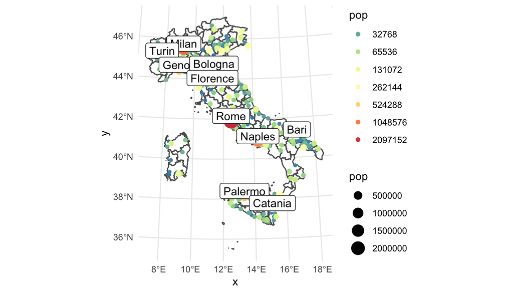

```r
city_geo_lgl <- city_geo %>%
  arrange(desc(pop)) %>%
  slice(1:10)

province %>%
  st_transform(7794) %>%
  ggplot() +
    geom_sf(fill = "white") +
    geom_sf(aes(size = pop, color = pop), data = city_geo) +
    geom_sf_label(aes(label = city_name), data = city_geo_lgl, nudge_y = 3e4) +
    scale_color_distiller(
      trans = "log2", palette = "Spectral", guide = "legend", n.breaks = 10
    )
```

### Window Functions

Compute the floor of each date value in the `covid` dataset. Group by this weekly date and summarize the total number of cases across all of the provinces. Use the `lag` function to create a column called `color` that is “#cc241d” (red) when the number of cases increases over a week and “#458588” (green) when the number of cases decreases over a week. Create a plot with the data with date on the x-axis and the number of cases on the y-axis. Use a geom_segment layer showing that starts at the number of cases in the previous week and ends at the number of cases in the current week. Color the segments with the color variable you created and set the size to 1.

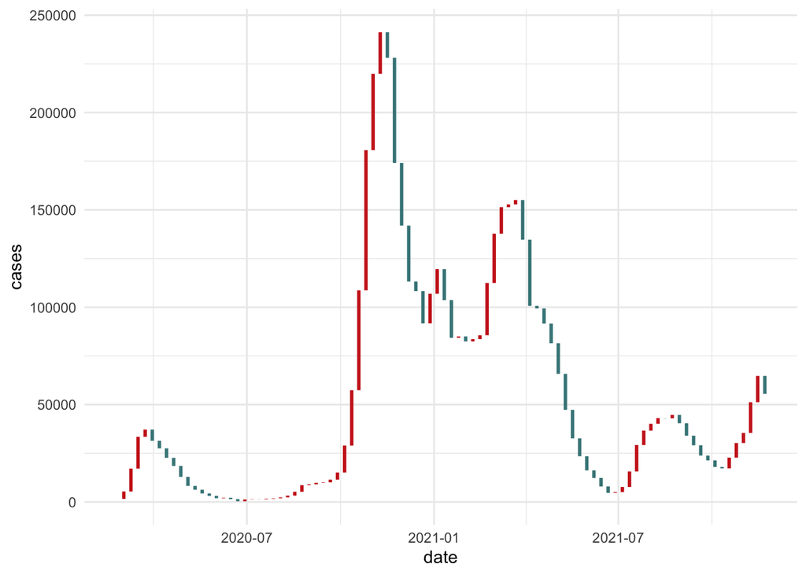

```r
covid %>%
  mutate(date = floor_date(date, "week")) %>%
  group_by(date) %>%
  summarize(cases = sum(cases)) %>%
  mutate(cases_lag = lag(cases)) %>%
  mutate(color = if_else(cases > cases_lag, "#cc241d", "#458588")) %>%
  ggplot(aes(date, cases)) +
    geom_segment(aes(xend = date, yend = cases_lag, color = color), size = 1) +
    scale_color_identity()
```

Below, again compute the number of cases each week. Filter the data to only include weeks that are local maxima: the number of cases was lower in the week before and after a given week.

```r
covid %>%
  mutate(date = floor_date(date, "week")) %>%
  group_by(date) %>%
  summarize(cases = sum(cases)) %>%
  mutate(cases_lead = lead(cases), cases_lag = lag(cases)) %>%
  filter(cases > cases_lead, cases > cases_lag)
```

```
## # A tibble: 10 × 4
##    date        cases cases_lead cases_lag
##    <date>      <dbl>      <dbl>     <dbl>
##  1 2020-03-23  37169      31415     33459
##  2 2020-06-08   2178       1448      1926
##  3 2020-07-06   1415       1336      1285
##  4 2020-11-09 241268     228124    219879
##  5 2021-01-04 119599     103667    106923
##  6 2021-01-25  85027      82408     84299
##  7 2021-03-22 155050     134703    152810
##  8 2021-08-09  43057      42962     40126
##  9 2021-08-23  44712      40415     42962
## 10 2021-11-15  64735      55514     51228
```

### Spatial Join

Using a spatial join, combine the `city_geo` with the `province` data. Compute the sum of the population of all cities in each province, convert the data to a tibble (use `as_tibble`, this removes the spatial metadata) and select just the `province` and `pop` columns. Save the result as a data set named `prov_pop`.

```r
prov_pop <- city_geo %>%
  spatial_join(province) %>%
  group_by(province) %>%
  summarize(pop = sum(pop)) %>%
  as_tibble() %>%
  select(province, pop)

prov_pop
```

```
## # A tibble: 103 × 2
##    province                 pop
##    <chr>                  <dbl>
##  1 Agrigento             160712
##  2 Alessandria           144153
##  3 Ancona                207039
##  4 Arezzo                 76346
##  5 Ascoli Piceno          87614
##  6 Asti                   61254
##  7 Avellino               48104
##  8 Bari                  867721
##  9 Barletta-Andria-Trani 329296
## 10 Belluno                25064
## # … with 93 more rows
```

Finally, use a left join to combine `province` and `prov_pop`. Create a spatial plot of the populations of the cities in each province using the fill aesthetic and a `scale_fill_distiller` scale.

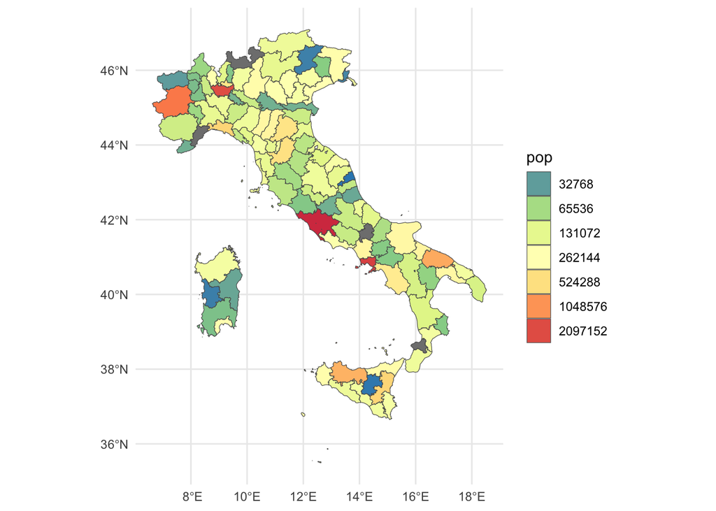

```r
province %>%
  left_join(prov_pop, by = "province") %>%
  ggplot() +
    geom_sf(aes(fill = pop), size = 0.2) +
    scale_fill_distiller(
      trans = "log2", palette = "Spectral", guide = "legend", n.breaks = 10
    )
```